# MADS-DAV · Lesson 5 · Modelling relationships

[figure not shown]

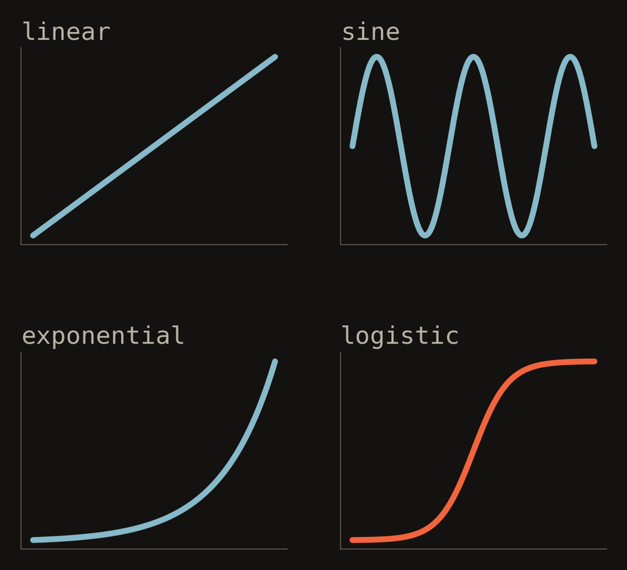

MADS-DAV

Data Analysis & Visualisation

# Modelling relationships

Why a simple model you understand beats a complex one you don’t, how to build one step by step, and when to believe what it shows.

Lesson 5

Hogeschool Utrecht

Lesson 5. Last week ended on a residual: a straight line that described Dutch COVID deaths well until January and then stopped working. Today is about modelling relationships, and about the step most people skip: deciding whether what you found means anything. Six questions. The first two are about what a model is and why simple models are worth so much. The third is the heart of the lesson: building the COVID model step by step, where every step is a piece of reasoning that ends up as a line of code. The last three are about believing a pattern: the trap of looking at too many things, what a correlation hides, and a model that is right for the wrong reason. Same rhythm as before: a question, real data with a reading guide, then the answer again in plain words. The four drawings on the cover are the four shapes of today: line, sine, exponential and logistic; the logistic is the one that comes back at the end of the COVID case.

Agenda

six questions

## Six questions for today

01

What is a model?

A simplification you choose. Never the whole truth, and never neutral.

02

Why keep a model simple?

A computer can fit anything. People can only understand simple shapes.

03

How do you build a model?

Look at the data, think about the world, add one thing. The COVID case.

04

When should you believe a pattern?

If you look at enough things, you always find something.

05

What can a correlation hide?

A variable you left out can reverse a correlation, or create one.

06

Can you recognise someone by how they type?

A model that works can still be right for the wrong reason.

▲ the question

■ real data, with a reading guide

● the answer again, concretely

Agenda

MADS-DAV · 2

The agenda as six questions; read them out. One and two are about models in general: what a model is, and why a simple one is often the better one. Three is the case we spend most time on: deaths and positive tests in the Netherlands, built step by step. Four, five and six are about believing what you find: a pattern can be chance, a correlation can be made by a variable you left out, and a model can be right for a reason that does not generalise. Each question gets the same three steps: the question, real data, and the answer again in plain words. The notebooks follow along: 05.1 relationships and believability, 05.2 correlation, 05.3 and 05.4 the COVID model, 05.5 how people type.

▲ question 01

what is a model?

## A model is like a map: useful because it leaves things out.

1 · Not true

A model is a simplification. It is never the real thing, just as a map is never the landscape.

2 · Not objective

You choose the shape, the variables and the data. Someone else could choose differently, with the same data.

3 · Useful

A good simplification shows you something you could not see in the raw numbers.

3

Question one. Two ideas almost every student brings in, usually without saying them: that a model is true, the real relationship that the data reveals, and that a model is objective, something the computer finds for you. Both are wrong, and both cause trouble later today. 'The map is not the territory' is Alfred Korzybski's phrase. A map of Utrecht that showed every stone would be as big as Utrecht and useless. A map is useful because someone decided what to leave out, and a different map maker, with a different purpose, leaves out different things. Models are the same: you choose what goes in. That does not make them arbitrary. It makes them claims, which you have to be able to defend.

■ 1 — what is a model?

the map is not the territory

## Leonardo’s earth: not true, still useful

[figure not shown]

Leonardo da Vinci drew the earth as a circle and a triangle, in his notebook on water and the earth (early 1500s).

He knew very well earth and the oceans look different.

Sometimes it is more interesting to ask: what does the model show me, than to strive for absolute truth.

1 / what is a model?

Codex Leicester, folio 35v (detail) · 4

Leonardo da Vinci, Codex Leicester, folio 35v, a detail: a geometric model of the earth, a circle and a triangle drawn into the text, in mirror writing. Nobody, Leonardo included, thought the earth looked like this. He drew it because a geometric shape lets you reason about something too big and too complicated to see whole. That is the point of this slide, and of the lesson: a model is a deliberate simplification. Judge it by what it lets you see and what it hides, not by whether it is true. Every model you will fit today is wrong in this sense, including the good ones. (The picture is a photograph of a book reproduction; the folio and the caption 'geometric model of the Earth' come from that book.)

■ 1 — what is a model?

398 cars · weight and fuel economy

## Three lines through the same cars

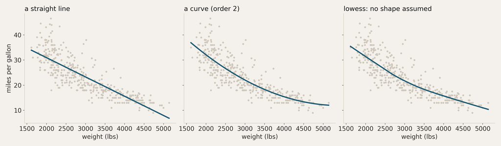

Left: a straight line says “every extra pound costs the same”. It misses the bend: too low for the lightest and heaviest cars.

Middle: This model has an extra parameter which allows it to follow the bend.

Right: lowess draws what the data shows, without a formula. Use it to look; choose a formula once you know the shape.

1 / what is a model?

MADS-DAV · 5

Notebook 05.1 starts here. Same 398 cars, three lines, and each line is a claim about what kind of relationship this is. The straight line is not stupid: r squared is 0.69 and the p-value is around 10 to the minus 103. Both numbers are true and neither tells you the line has the wrong shape; the picture tells you immediately. The line sits below the lightest and the heaviest cars and above the ones in the middle: it is averaging a curve. A polynomial of order 2 follows the bend. Lowess finds the same bend without being told there is one. The rule of thumb from the notebook: lowess first, as a description, when you do not know the shape; then a formula once you have decided what the shape is, because a formula has parameters you can read and can extrapolate. One more choice: on log-log axes the line says doubling the weight roughly halves the miles per gallon (times 0.48). That is a claim about ratios, and a sentence people can understand. Which of these is the true one? None. They are three claims; you pick the one you can defend.

● 01 — again, concretely

The map is not the territory.

A model is a simplification you choose: the shape, the variables, the slice of data.

So it is not true and not objective. It is a simplification, and its value often lies in the simplification.

If you choose anyway, why choose something simple? That is the next question.

6

Said again. Students often hand in a model as if the data produced it. It did not: you chose the shape, the variables and the window. That is not a weakness, it is the job. The weakness is not knowing you chose.

▲ question 02

why keep a model simple?

## A computer can find very complex patterns. People can only understand simple ones.

1 · Precision

A deep learning model can have millions of parameters. It may predict well, but we can only understand the artefacts it produces

2 · insight

Four simple shapes cover a surprising amount of the world: line, sine, exponential and logistic. These models tell a story.

3 · Restriction

A model that can fit too much tells you nothing. A simple model can fail, so when it fits, that means something.

7

Question two. Deep learning can find extremely complex patterns, and for prediction that is often what you want. But our capacity for complexity is limited: you cannot hold a million parameters in your head, explain them to a client, or check them against what you know about the world. Simple patterns stay useful because they are comprehensible: you can say them out loud and someone can argue with you. This section has three parts: four shapes worth knowing by name, why a more flexible model is not a better one, and a story about a number nobody understood.

■ 2 — why keep a model simple?

the four horsemen of modelling

## Four shapes worth knowing by name

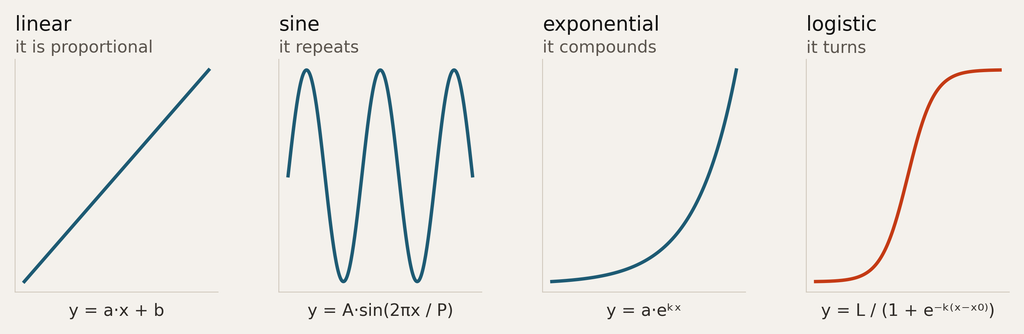

Linear: twice as much in, twice as much out. Price per kilo, deaths per positive test.

Sine: comes back on a fixed rhythm: days, weeks, seasons.

Exponential: every step multiplies by the same factor. Interest, the start of an epidemic.

Logistic: grows, then levels off at a limit. Or switches from one level to another.

2 / why keep a model simple?

MADS-DAV · 8

The four horsemen of modelling: linear, sine, exponential, logistic. Students should know them by sight and by name, because each one is a sentence. A line says proportional: double the input, double the output. A sine says it repeats: the same pattern every week or every year. An exponential says it compounds: every step multiplies by the same factor, so it grows faster and faster. A logistic says it turns: it grows like an exponential at first, then slows down and levels off at a ceiling; turned around, it is a switch from one level to another. Many real models are one of these, or two of them added or multiplied. You will see the sine on airline passengers in a moment, and the logistic in the COVID case.

■ 2 — why keep a model simple?

duckweed on a pond · an illustration

## Nothing in nature grows exponentially for long

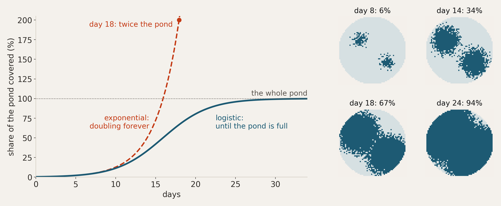

Duckweed on a pond. While there is room it doubles every two days: exponential growth.

Keep doubling and on day 18 it covers twice the pond. That can’t happen: the pond is full, and the growth stops.

That is a logistic: exponential at first, then a ceiling. Every living system hits one. It comes back in the COVID case.

2 / why keep a model simple?

illustration, not measured data · 9

Most people have seen a pond slowly turn green with duckweed or algae. The old riddle: duckweed doubles every day and covers the whole pond on day 30; on which day was it half covered? Day 29, because the last doubling covers the second half. That riddle is pure exponential growth, and it is why exponential growth surprises people: for a long time almost nothing seems to happen, and then everything happens at once. A real pond adds the part the riddle leaves out: the pond is only so big. Here an illustration, not measurements: duckweed that starts on 0.4 percent of the pond and doubles every two days while there is room. The exponential keeps doubling and covers twice the pond on day 18, which cannot happen. The logistic has the same start and the same doubling, and slows down as the free water runs out: half covered on day 16, nearly full by day 25. Biological and natural systems never grow exponentially for long, because something always runs out: room, food, light, or for an epidemic the people it can still infect. That is what the logistic says: exponential at the start, a ceiling at the end, a turning point halfway. Remember the shape and the idea of a natural limit: the COVID model at the end of question three uses the same curve, turned downward.

■ 2 — why keep a model simple?

airline passengers · 1949–1960

## A line plus a sine: four numbers, 93% explained

exercise

notebook 05.4 · §5.4.3 “a wave that grows”

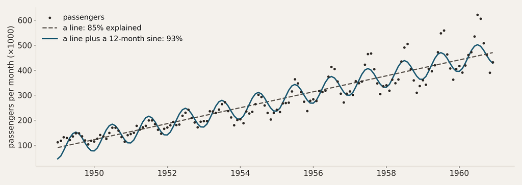

A line alone: about 2,650 more passengers every month. That explains 85% of the variation.

Add a sine that repeats every 12 months, the summer peak. Four numbers in total, and 93% explained.

What is left is visible: the real swing grows with the trend, the sine stays the same width. What in a sine sets its height, and how would you let it grow?

2 / why keep a model simple?

MADS-DAV · 10

From notebook 05.4. Monthly passengers, 1949 to 1960, in thousands. A straight line in time gets 85 percent of the variance: the trend. Adding one sine with a period of twelve months, which costs two extra numbers, an amplitude and a phase, lifts that to 93 percent. Four numbers in total, and you can say each of them out loud: how much the trend grows per month, how big the summer peak is, and when in the year it falls. The gap that remains is honest and readable: the real summer swing gets wider as the trend grows, and a sine added on top of a line keeps the same width. You can only see that because the model is simple enough to read. The question on the slide is an exercise in notebook 05.4 (section 5.4.3, 'a wave that grows'), so let the room think about it rather than answer it here. If they get stuck: which parameter of the sine sets its height, and what should that height depend on? Whether the new piece is added or multiplied is the same decision as the COVID switch later today. An honest answer lifts the explained variance from 93 to about 95 percent.

■ 2 — why keep a model simple?

fit the pattern, not the noise

## A better fit is good, until you fit the noise

precision

You want a model that fits better…

…but push too far and it starts to fit the noise: the accidents of this one sample. Last weeks insight: we can model the noise. Give it its own term, ε, instead of chasing it.

insight

Sometimes the goal is people…

…a result someone can read, check and act on. The artefact you hand over has to be understandable: what you don’t understand, you can’t work with.

Fit the pattern, give the noise its own term, and hand over something people can understand.

2 / why keep a model simple?

MADS-DAV · 11

Of course you want a model that fits better; that is what fitting is for. The problem is going too far. Every dataset is one sample, with its own accidents in it, and a model flexible enough to follow every point follows the accidents too: it models the noise. Last week gave the alternative: noise is a factor in its own right, and you can model it. Give it its own term, epsilon, say what distribution you expect, and check the residual against it, as the COVID model does today. A simple model is forced to leave the noise alone, which is why its fit means something; the next two slides show that. The second point is about the goal. Sometimes the goal is prediction, and then a complex model, a neural network, is fine: nobody needs to read its weights. But often the goal is communication between people: a plot, a formula, a number with a sentence that someone else has to understand, check and act on. That artefact may well have been produced with the help of a complex model; it still has to be understandable, because people cannot work with what they do not understand. Precision and insight are different goals, and the four simple shapes serve the second.

■ 2 — why keep a model simple?

12 cars · real and shuffled

## A model that can fit anything tells you nothing

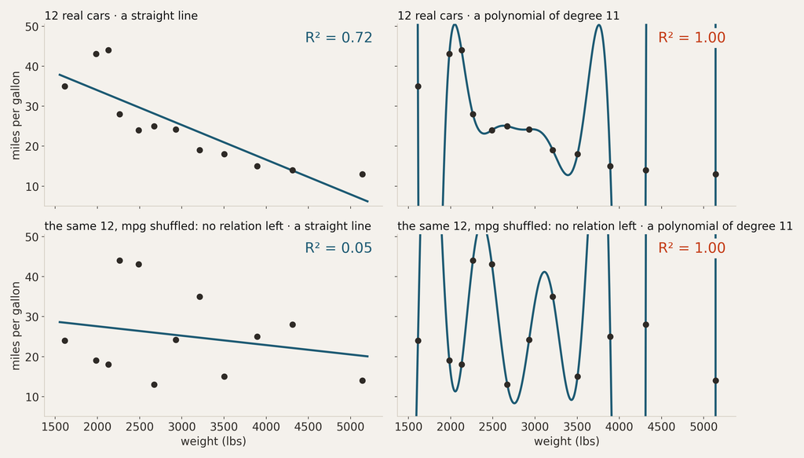

Top: 12 real cars. The line fits reasonably, R² = 0.72. A polynomial of degree 11 goes through every point: R² = 1.00.

Bottom: the same cars with the mpg shuffled, so weight says nothing any more. The line notices: 0.05. The polynomial does not: 1.00 again.

The line can fail, so its 0.72 tells you something about cars. The polynomial cannot fail, so its 1.00 tells you nothing.

2 / why keep a model simple?

MADS-DAV · 12

The intuition in one picture. Twelve cars from the same dataset, spread over the weights. Top row: the real data. The straight line explains 72 percent of the variation. A polynomial of degree 11 has twelve parameters for twelve points, so it can go through every single one: R squared 1.00, a perfect score. Bottom row: the same twelve weights, with the fuel economy values shuffled between the cars. There is no relationship left; any pattern is chance. The straight line sees that: 0.05. Over 200 shuffles its median is 0.05, and 95 percent of shuffles stay below 0.28. The polynomial gets a perfect 1.00 again, on nonsense. A model that scores perfectly on real data and on nonsense cannot tell them apart, so its score is worthless. This is the same shuffle as last week: ask what you would see if there were nothing there.

■ 2 — why keep a model simple?

the same 12 cars · and 386 it never saw

## Too simple, about right, too flexible

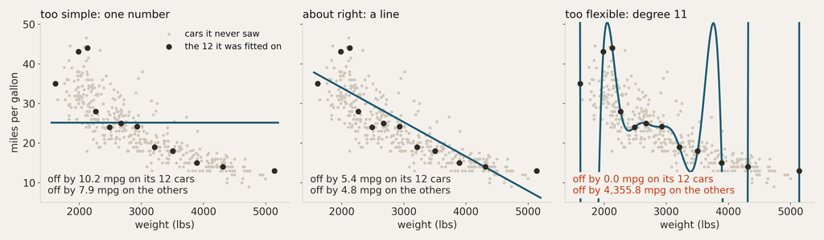

Too simple (underfitting): one number for every car. Wrong on its own 12 cars, wrong on the rest. It misses the pattern.

About right: a line. A bit wrong on its 12 cars, and about as wrong on cars it never saw. It learned the pattern.

Too flexible (overfitting): perfect on its 12 cars, off by thousands of mpg on the others. It learned the 12 cars, not cars.

2 / why keep a model simple?

MADS-DAV · 13

The usual names. Underfitting: a model too simple for the pattern, here a single number, the mean, for every car. It is about ten mpg off on the cars it was fitted on and about eight on the others: bad everywhere, but at least honestly bad. A straight line is about five mpg off on both: it learned something that carries over to cars it has never seen. Overfitting: the polynomial of degree 11 is zero mpg off on its own twelve cars and, on average, more than four thousand mpg off on the other 386 cars in the same weight range, because between the points it swings wherever it likes. The tell-tale sign of overfitting is exactly this gap: very good on the data it saw, bad on new data. Lesson 6 gives this its own machinery, with train and test sets. For today the intuition is enough: you want a model that is about as wrong on new data as on old.

■ 2 — why keep a model simple?

a real student assignment and its defence

## If you can’t explain a number, don’t report it

| model | MAPE | MAE | RMSE |
| --- | --- | --- | --- |
| Random Forest | 4.78e+13 | 0.89 | 2.5 |
| XGBoost | 5.48e+13 | 0.53 | 1.3 |
| KNN regressor | 6.48e+13 | 1.46 | 3.74 |

“These results suggest that the model is a robust and reliable tool for predicting power draw of the engine…”

“…the extreme high values suggest either that there are extreme outliers in the data or that MAPE is not a well-suited metric…”

Source: a real student’s assignment and its defence.

Six slides of MAPE formulas, all generated. Then the question: what does a MAPE of 10¹³ mean, and what follows from it? If all you can do is guess, you missed the insight.

Don’t copy numbers you don’t understand, and don’t let an LLM make your presentation without understanding what is going on. A number you can’t explain is not a result.

2 / why keep a model simple?

MADS-DAV · 14

This comes from a real assignment a student handed in, and from the defence of it, in this course. The task: predict the power draw of an engine. In the defence the student showed this table and six slides of MAPE formulas, all generated. The sentences on the left sound professional: the model is robust and reliable, and the extreme MAPE suggests outliers or an unsuited metric. Then the questions: what do you think of a MAPE with this value, what does it mean, and what consequences do you attach to it? It was clear there was no understanding at all. The MAE column is no better. An MAE of 1.46 means nothing until you compare it with a baseline error, for instance the error of always predicting the average. If that baseline is 0.001, then 1.46 is bizarrely high; if it is 100, the model is excellent. Without the baseline nobody, the student included, can say whether the model is any good. This is the warning for the whole course: do not be the student who copies numbers, has no idea what they mean, and lets an LLM make the presentation. Use the tools, but every number on your slides is one you must be able to explain and defend. (If someone asks why MAPE can reach ten to the thirteenth: it divides each error by the true value, so true values at or near zero blow it up. The student could not say that, and that is the point.)

● 02 — again, concretely

A simple model can fail, and that is a signal you can use.

Complex models find complex patterns, but you can’t read them.

Start simple. Add a term only when what is left over has a shape you recognize.

If a model fails, that can be a very interesting signal that tells you something about reality.

15

Said again. Four shapes, each a sentence. A flexible model is not closer to the truth; it is closer to the noise. And a number you cannot explain does not belong in a report, however it was produced. Now the case where all of this comes together.

▲ question 03

how do you build a model?

## Look at the data, think about the world, add one thing. Then look again.

1 · Look

Plot the data and notice what is strange: noise, a delay, a difference in size.

2 · Think

Use what you know about the world: how a disease progresses, how reporting works, when the vaccine came.

3 · Add

Turn each piece of reasoning into one step in the pipeline, or one term in the model.

16

Question three, the heart of today. Public Dutch COVID figures: positive tests and deaths per day, October 2020 to June 2021. The model in the end is small, but the way there is the lesson. Every step goes the same way: you look at the data, you notice something, you think about what you know about the world, and you add one thing. Five steps, and each one ends up as a line in the pipeline or a term in the model. Notebooks 05.3 and 05.4 follow the same path, and scripts/covid_pipeline.py holds the whole loop as a script.

■ 3 — how do you build a model?

step 0 · the deaths as delivered

## Step 0 · A running total. How many died per day?

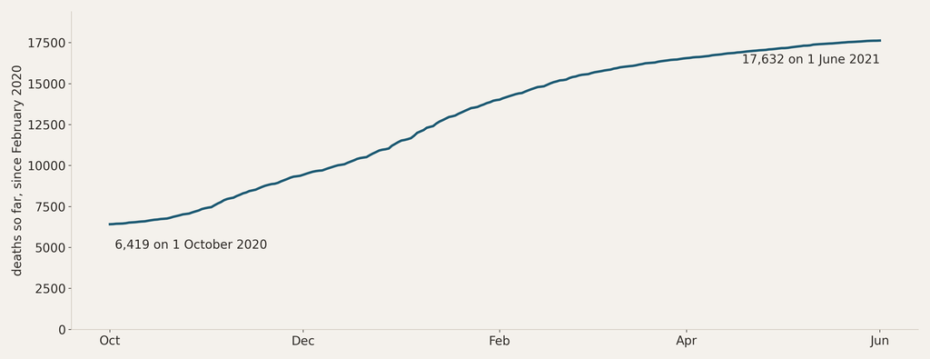

3 / how do you build a model?

MADS-DAV · 17

Take the difference with the day before: deaths today = total today − total yesterday.

pipeline

.add(DiffValues, column="deaths")

Step zero: the data as it arrives. The Dutch figures give deaths as a running total: everyone who has died of COVID since February 2020, 6,419 on 1 October 2020 and 17,632 on 1 June 2021. The line can only go up, and the number that matters is hidden in how steep it is. Ask the room: how do you get the number of deaths per day out of this? Then click: take the difference with the day before. Today's total minus yesterday's total is today's deaths. In the pipeline that is the first step, DiffValues on the deaths column. The next slide shows what comes out.

■ 3 — how do you build a model?

step 1 · dutch covid · oct 2020 – jun 2021

## Preattentive processing: what do you see?

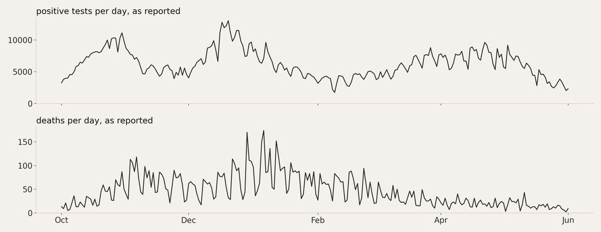

3 / how do you build a model?

MADS-DAV · 18

What jumps out first is the weekly cycle: every week few deaths are reported on Sundays and Mondays, and a peak on Tuesdays.

Step one starts with looking, before any answer. Preattentive processing: in the first fraction of a second, before anyone reads an axis or a number, the visual system has already picked out what stands out: repetition, contrast, a pattern that keeps coming back. So show the numbers exactly as reported and ask the room what they see. Give it a few seconds. Then click: what jumps out first is the weekly cycle, strongest in the deaths. On average about 25 deaths are reported on Sundays and Mondays and 67 on Tuesdays. People do not die less on Sundays; registration waits for the weekend to end and catches up after. Strong as it is, it is not what we want to model. The next slide is what to do about it.

■ 3 — how do you build a model?

step 1 · dutch covid · oct 2020 – jun 2021

## Step 1 · Too much noise: average over a week

pipeline

.add(RollingAvg, column="positivetests", window=7)

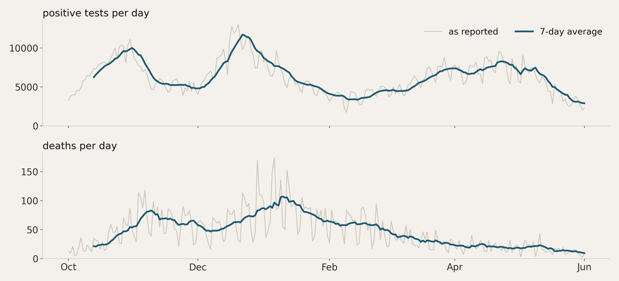

Grey: the numbers as reported each day. Deaths jump every week: about 25 reported on Sundays and Mondays, 67 on Tuesdays.

We are not interested in the weekcycle; that tells us more about society, less about the disease.

Petrol: the average over the last 7 days. The weekly rhythm cancels out, and the course of the epidemic is left.

3 / how do you build a model?

MADS-DAV · 19

Step one, the answer to the previous slide. The grey line jumps up and down with a weekly rhythm. On average about 25 deaths are reported on Sundays and Mondays and 67 on Tuesdays. People do not die less on Sundays; deaths are registered less in the weekend and caught up on Tuesday. That is a fact about the administration, not about the disease. Knowing that, the fix is obvious: average over seven days, so every average contains each weekday exactly once. The weekly rhythm cancels and the course of the epidemic remains. In the pipeline: RollingAvg with a window of 7, on the deaths and on the tests.

■ 3 — how do you build a model?

step 2 · knowledge from the literature

## Step 2 · Deaths come about two weeks after a positive test

pipeline

.add(ShiftValues, column="deaths", period=-14)

model

deaths(t) = a · tests(t − 14)

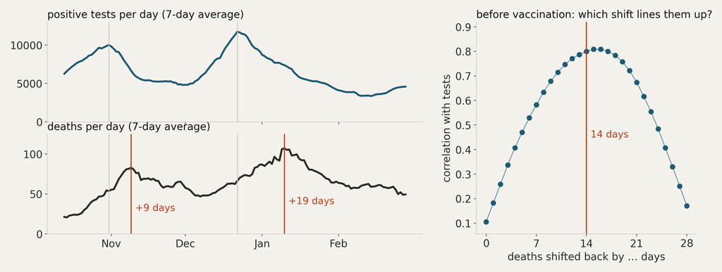

From the literature: from a positive test to death takes about two weeks. You know this before you look at the data.

Left: tests peak, deaths follow. 9 days later in November, 19 days later in January.

Right: one correlation for every shift of 0 to 28 whole days. The best ones lie around 14–16 days: the data agrees.

3 / how do you build a model?

MADS-DAV · 20

Step two. Someone who tests positive and dies of the disease usually does so some two weeks later: infection, illness, hospital, death. That is knowledge from outside the data, from the medical literature. So the deaths recorded fourteen days from now are the deaths of today's positive tests, and a model between the two should pair them that way. The left panel shows it with the naked eye: the deaths peak after the tests, 9 days later in November, 19 days later in January. The right panel checks it: shift the deaths back by 0, 1, 2 and so on up to 28 whole days, and compute the Pearson correlation with the tests before vaccination for each shift. That is 29 separate measurements; the thin line only guides the eye. The best shift is around 14 to 16 days. Note the order: the 14 comes from the literature, and the data confirms it. If we had searched the data for the best lag and used that, we would be searching again, like last week's search for the day. In the pipeline: ShiftValues with period -14. This is also where the model starts: deaths(t) = a · tests(t − 14), a fixed share a of the positive tests two weeks earlier. No b and no noise yet; they come one at a time, later in this step-by-step.

■ 3 — how do you build a model?

step 3 · oct 2020 – jan 2021

## Step 3 · Tens against thousands: compare with z-scores

pipeline

.add(ZScaler, column="positivetests", rename=True)

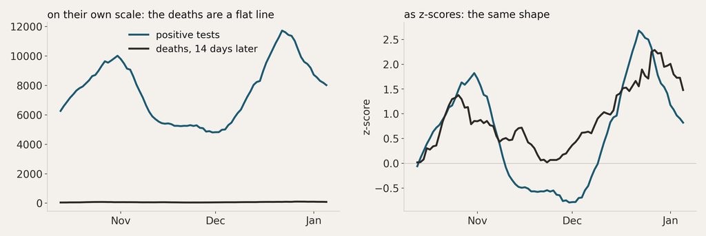

Left: tests run in the thousands, deaths in the tens. On one axis the deaths are a flat line at the bottom.

A z-score takes off the mean and divides by the standard deviation: (x − mean) / sd. Every series becomes “how unusual is today”.

Right: as z-scores, the deaths two weeks later follow the shape of the tests. The z-scores are for looking; the model uses the counts.

3 / how do you build a model?

MADS-DAV · 21

Step three. You want to see whether the two series have the same shape, but they live on different scales: thousands of positive tests a day, tens of deaths. On one axis the deaths disappear. A z-score puts every series on the same scale: subtract its own mean, divide by its own standard deviation. Zero is an average day for that series, plus two is a very unusual one. Now the deaths, shifted two weeks back, follow the tests: up in the autumn wave, down in November, up again in December. Students know z-scores; the point here is why you use one: to compare shapes, not sizes. The z-scores are only for looking. The model in step 5 works on the real counts, because the ratio between deaths and tests is the thing we want to estimate. In the pipeline: ZScaler on both series.

■ 3 — how do you build a model?

step 4 · knowledge from outside the data

## Step 4 · Add what you know: vaccination started on 6 January

pipeline

.add(SelectDataRange, start_date=…, end_date=…)

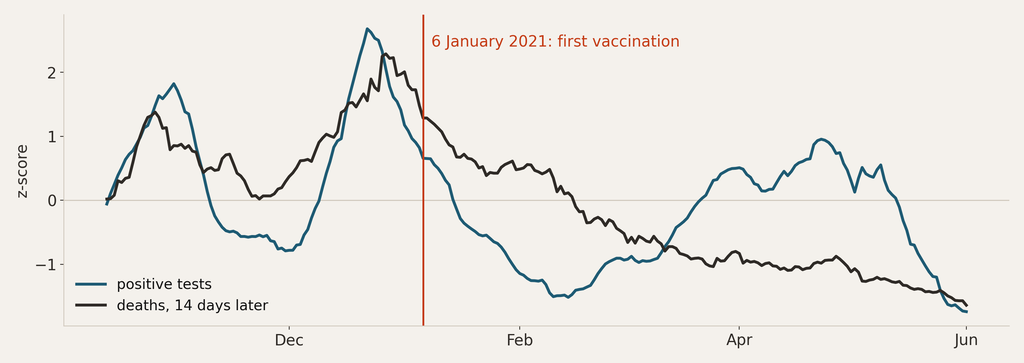

The whole window, as z-scores. Until January the two curves move together.

From February they part: tests rise again in spring, deaths keep falling.

The data does not say why. You know something it doesn’t: the first vaccination in the Netherlands was on 6 January 2021.

3 / how do you build a model?

MADS-DAV · 22

Step four. Over the whole window the picture changes: until January the curves move together, from February they part. Tests climb again in the spring, deaths keep going down. The data cannot tell you why; it has no column for it. You know something it does not: on 6 January 2021 the first vaccination was given in the Netherlands. That date becomes part of the analysis as knowledge from outside the data. It does two things. It tells us where the relationship between tests and deaths is likely to hold, before vaccination, so that is where we fit the first model. And it gives us a guess for where something might change. In the code: VACCINATION_START = '2021-01-06', used to select the window. The pipeline's SelectDataRange makes the same kind of decision for the whole study: which months, here 1 October 2020 to 1 June 2021.

■ 3 — how do you build a model?

the line · 85 days before vaccination

## Add b: the deaths the tests don’t explain

deaths(t) = a · tests(t − 14)

deaths(t) = a · tests(t − 14) + b

a = 0.0065: of every 100 positive tests, 0.65 end in death two weeks later.

b = 20 deaths a day, even at zero positive tests: people who would die anyway, whom the tests don’t account for.

Without b (dashed) the line has to go through zero, and a has to do all the work: steeper, and further off.

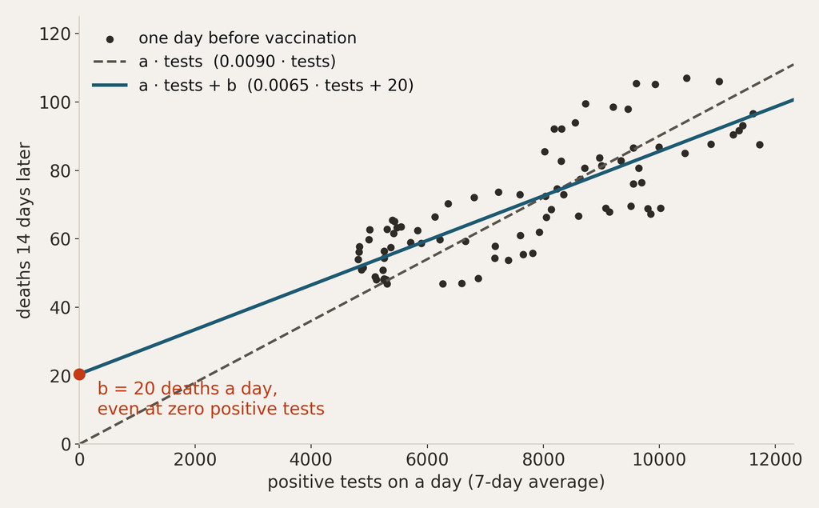

3 / how do you build a model?

MADS-DAV · 23

One more term before the noise, and give it time. Step two gave deaths(t) = a · tests(t − 14): every death comes from a positive test two weeks earlier. Fit that on the 85 days before vaccination and the line has to go through zero: the dashed line, with a = 0.0090. Now add a constant b, so the line may start higher. The fit puts b at about 20 deaths a day and a at 0.0065, 0.65 deaths per hundred positive tests. What b means: deaths that happen whatever the number of positive tests, people who would die anyway, or who were never tested. One caution for the room: no day in this window had fewer than about 4,800 positive tests, so b is where the line meets zero tests, an extrapolation. Read it as the deaths the tests do not account for, not as a measured count. With b the line is closer to the points: the mean squared error drops from 127 to 99. Only now, on the next slide, comes the noise.

■ 3 — how do you build a model?

step 5 · oct 2020 – 5 jan 2021

## Step 5 · Say how wrong the model is allowed to be

deaths(t) = a · tests(t − 14)

deaths(t) = a · tests(t − 14) + b

deaths(t) = a · tests(t − 14) + b + ε

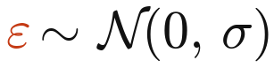

ε: everything the line doesn’t explain, treated as chance: normally distributed around 0, with σ = 10 deaths a day.

98% of the days fall inside ± 2σ. That is what “allowed to be wrong” means, and it can be checked.

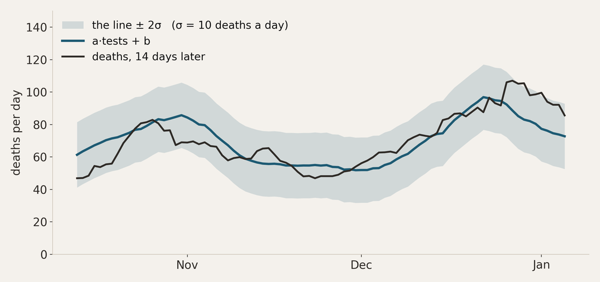

3 / how do you build a model?

MADS-DAV · 24

Step five, the last term. The model so far: a fixed share a of the positive tests two weeks earlier, plus b, the deaths the tests do not explain. Now the noise. Writing down epsilon is a claim: everything the line does not explain is chance, normally distributed around zero with a standard deviation sigma, here about ten deaths a day. That is modelling the uncertainty: the model says not only what it expects, but how far off it is allowed to be. Plus or minus two sigma should hold about 95 percent of the days; it holds 98 percent of the 85 days before vaccination. And because it is a claim, it can be checked: if the errors stop looking like chance, the model is missing something. That is the residual from last week, and goad's DistributionFitter is the tool that checks it.

■ 3 — how do you build a model?

the reasoning, the pipeline, the model

## Every step of reasoning becomes a line of code

the pipeline · CovidDataProcessor

DiffValues

a running total of deaths; you want deaths per day

→

ShiftValues(-14)

deaths come about two weeks after a test: the literature

→

SelectDataRange

the months you want to study

→

RollingAvg(7)

weekends are society, not disease

→

ZScaler

tens against thousands: compare the shapes

the model

deaths(t) = a · tests(t − 14) + b + ε

tests(t − 14): the same two weeks as ShiftValues(-14), now in the formula.

a and b: fitted on the days before 6 January, a date from outside the data.

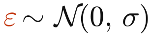

What the line can’t explain is treated as chance, and can be checked.

3 / how do you build a model?

MADS-DAV · 25

This is the slide to stay on. Every step of reasoning from the last five slides ends up in one of two places: the pipeline that prepares the data, or the formula of the model. Top row: CovidDataProcessor, the goad pipeline the notebooks use, is exactly these five steps in this order. You see a running total, you want deaths per day: DiffValues. You know from the literature that deaths come about two weeks after a test: ShiftValues with period minus fourteen. You choose the months you study: SelectDataRange. You know the weekly jump is the weekend administration: RollingAvg with a window of seven. You want to compare tens with thousands: ZScaler, only for looking. DataConfig holds the 14, the 7 and the window, so each decision has one place where it lives. Bottom row: the same reasoning in the formula. The two-week shift appears again as tests at t minus 14. The vaccination date decides where the line is fitted. And epsilon says the rest is chance, which is itself a claim the residual can check. Nothing here came out of the data by itself. Each step is a decision you can explain and point at, and that is why a pipeline is built from named steps instead of one long chain of pandas.

■ 3 — how do you build a model?

last week · all 232 days

## Previous lesson: the residual shows what the line misses

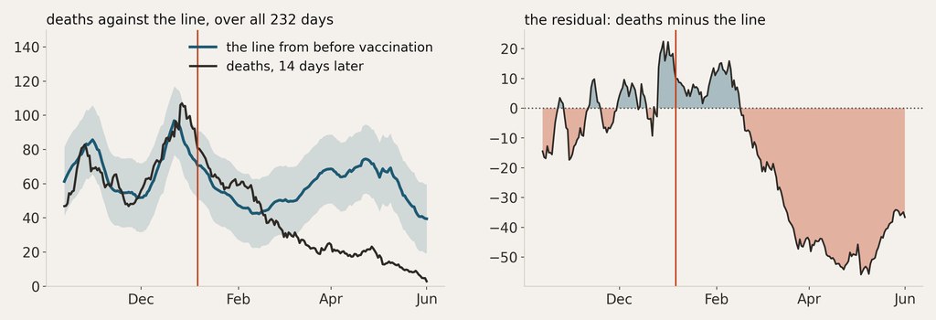

Left: the line from before 6 January, run over all 232 days. From February the deaths fall out of the band, and stay out.

Right: the residual, deaths minus the line. Below zero from 16 February to the end, at worst 50 deaths a day.

One fixed share of tests ending in death no longer works. Something changed the ratio, and the residual says roughly when.

3 / how do you build a model?

MADS-DAV · 26

You saw this last week, so briefly. Take the line exactly as fitted before vaccination, the same a and b, and run it over every day up to June. Nothing in it knows what month it is. Until January the deaths stay inside the band. From February they drop below it and never come back; 60 percent of the days after 6 January fall below the band. The residual on the right says the same thing: below zero from 16 February to the end, at its worst about fifty deaths a day. The errors are not chance any more; they have a shape, a long run in one direction. Last week's conclusion: the model misses a process, and the residual dates it. This week's question: how do you put that process into the model?

■ 3 — how do you build a model?

deaths per 100 positive tests

## How do you model a vaccine? Look at the ratio

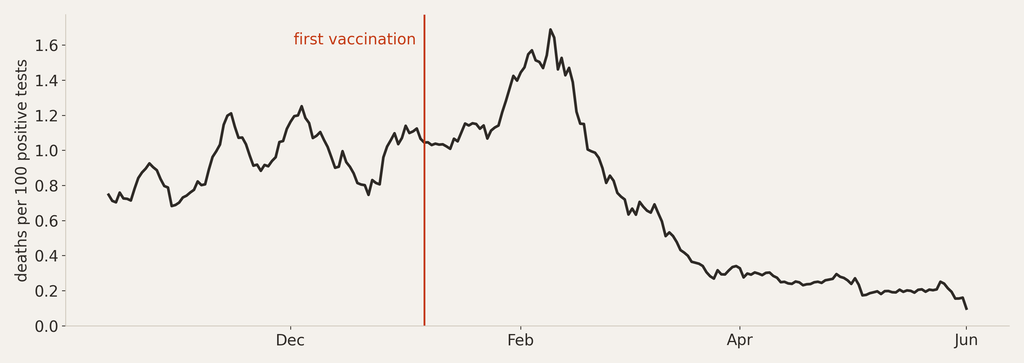

Deaths two weeks later per 100 positive tests: about 1 through the winter, 0.3 in April, 0.2 in May.

A vaccine doesn’t work on one day. The rollout went down the age groups, oldest first, over weeks. Once they are protected, the ratio settles lower.

One level, a turn over some weeks, a lower level. Which of the four shapes is that? A logistic, turned downward.

3 / how do you build a model?

MADS-DAV · 27

■ 3 — how do you build a model?

a logistic switch · two knobs

## A logistic switch has two knobs: when and how fast

model

deaths(t) = a · tests(t − 14) · s(t) + b + ε

switch

s(t) = 1 / (1 + exp(−k · (t − x0)))

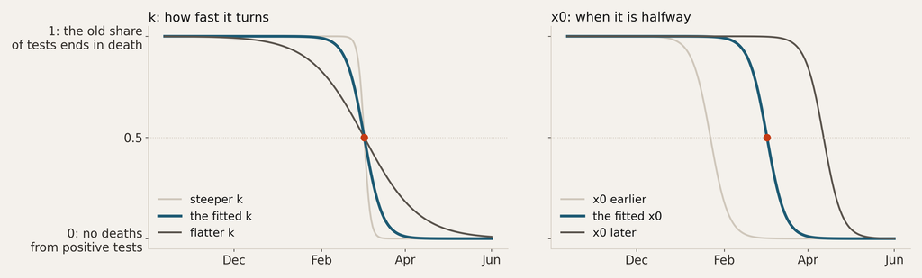

The switch s(t) starts at 1: of every positive test, the old share ends in death. It ends at 0: a positive test no longer leads to death.

x0 sets when: the day the switch is halfway. k sets how fast: a large k turns in days, a small k over months.

With the switch at 0, only b and ε are left: deaths that have nothing to do with positive tests, and the noise.

3 / how do you build a model?

MADS-DAV · 28

The vaccine needs a term, and the ratio slide said which shape: a logistic, running from one level to another. Before fitting it, look at what its two numbers do. The switch is s(t) = 1 / (1 + e^(−k(t − x0))). It starts at 1: every positive test carries its old risk, the a we fitted before vaccination. It ends at 0: being infected no longer leads to death. x0 is the day the switch is halfway, so it sets when the turn happens; k sets how steep the turn is, from a few days to several months. Left panel: the same x0 with a steeper and a flatter k. Right panel: the same k with x0 earlier and later. In the model the switch multiplies only the tests term: deaths(t) = a · tests(t − 14) · s(t) + b + ε. When the switch reaches 0, what remains is b, the deaths the tests never explained, and the noise. That is the claim: vaccination breaks the link between testing positive and dying, it does not make other deaths disappear.

■ 3 — how do you build a model?

four parameters · fitted together

## The switch, fitted: the date falls out of the fit

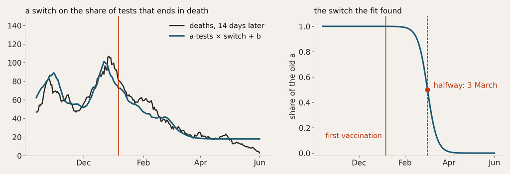

deaths(t) = a · tests(t − 14) · s(t) + b. Only the share of tests that ends in death switches off; b and the noise stay.

The fit puts the turn halfway on 3 March 2021, eight weeks after the first vaccination. By April the switch is close to 0.

a = 0.0071 and b = 18: close to the line from before vaccination (0.0065 and 20). The error drops from 800 to 66.

3 / how do you build a model?

MADS-DAV · 29

The fit. Four numbers: a and b from the line, k and x0 from the switch. The only help we gave the optimiser was a starting value for x0, about a month after the first vaccination, and bounds that say what each parameter may mean. It puts the halfway point on 3 March 2021, eight weeks after the first vaccination. The turn is fairly quick: the switch is still at 0.99 on 1 February, 0.58 on 1 March and close to 0 by 1 April. a comes out at 0.0071 and b at 18, close to the line we fitted on the days before vaccination (0.0065 and 20): the switch does not have to bend the line, it only takes the tests term away. The mean squared error drops from 800 for the line alone to 66. The form says what we mean: vaccination breaks the link between a positive test and death, the other deaths stay. Notebook 05.4 and scripts/covid_pipeline.py fit exactly this model.

■ 3 — how do you build a model?

is the model done?

## The residual looks like chance again

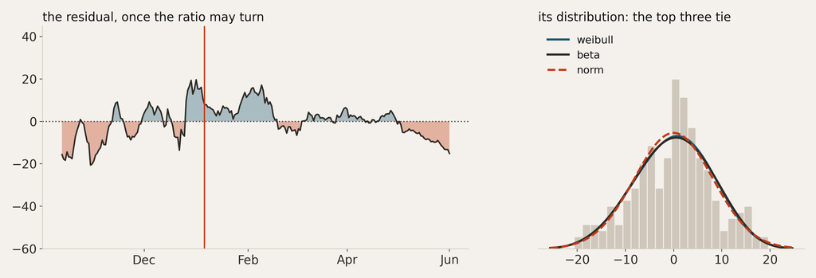

Left: no long run below zero until May. From May the model expects b = 18 deaths a day, and fewer happen.

Right: Weibull, beta and normal fit the errors almost equally well, none rejected. The data can’t tell them apart: that is what chance looks like.

The fit shows that the ratio turned, and when. Why it turned is a separate claim: the end of the winter wave and changes in testing sit on the same calendar.

3 / how do you build a model?

MADS-DAV · 30

Is the model done? Apply the bar from the previous lesson. No long structure over time until May: the long negative run after vaccination is gone, and what is left are waves of a few weeks around zero. A distribution the data cannot pin down: Weibull, beta and normal are within about one log-likelihood point of each other, and none is rejected by the KS test. From May the residual drifts below zero again: the model now says deaths are b, 18 a day, and fewer happen. That is the next thing a serious model would treat, for instance by letting b fall as well. Then the honest part. The model has a switch on the calendar, not a term for vaccination. The end of the winter wave, a change in who was being tested and the order in which age groups were vaccinated all sit on the same calendar, and each could produce a switch that fits. The fit dates the turn; the cause is a separate claim. Defending it needs other evidence: coverage by age group against deaths by age group, or the same fit on a country whose rollout started on a different date. That is question four.

■ 3 — how do you build a model?

scripts/covid_pipeline.py · drawn by atlas

## The whole loop as a map, drawn by atlas

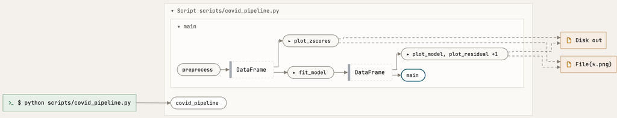

def main() -> None:  
data = preprocess()  
plot_zscores(data)  
data = fit_model(data)  
plot_model(data)  
plot_residual(data)  
plot_residual_distribution(data)  
logger.success("All done.")

Read it left to right: the command starts the script, preprocess makes a DataFrame, fit_model adds the prediction and the residual, the plots write PNG files.

A pill is a function, a box is where data rests: a DataFrame in memory, files on disk. Click a pill and atlas opens it into its own steps.

In the final assignment you use atlas to show how your own code works: run atlas view in your repository. Install it from github.com/raoulg/atlas.

3 / how do you build a model?

MADS-DAV · 31

The loop we just built also lives in scripts/covid_pipeline.py: six small functions and a main that runs them in order, with main's code on the left. Atlas draws what that code does. It does not show files and folders; it shows where data rests and the functions that carry it from one place to the next, in the order they run. Read the picture from left to right: the command python scripts/covid_pipeline.py starts the script; inside main, preprocess produces a DataFrame (the goad pipeline from the step-by-step), fit_model turns it into a second DataFrame with the prediction and the residual, and the plotting functions write PNG files to disk. A rounded pill is a function, a box with a bar is a value in memory, the orange boxes are files. Every function has a name you can guess the contents of and says what goes in and what comes out; when the code is clean, the picture is simple, and when the picture looks wrong, the code usually is. That is why the final assignment asks for it: students run atlas view in their own repository, pick their entry point in the dropdown, choose Flowchart, and click a pill to open it. Atlas is at github.com/raoulg/atlas, with an install script for macOS, Linux and Windows; it writes one HTML file and keeps the code on your own machine.

▲ question 04

when should you believe a pattern?

## If you look at enough things, you will always find something.

1 · Chance

Compare two random groups on enough things, and you will always find something that the statistics say is “significant”.

2 · Predict

A real pattern shows up again in data you have not looked at yet.

3 · Three legs

A model, a mechanism, and replication. Statistics only gives you the first.

32

Question four, from notebook 05.1. Last week you shuffled labels to see how big a difference chance makes for one comparison. Today: what happens when you make many comparisons, and what makes a finding believable at all. The data is the Ubuntu IRC chat channel you know from earlier lessons.

■ 4 — when should you believe a pattern?

irc #ubuntu-uk · 442 people · 15 measures

## Fifteen comparisons, one below the line

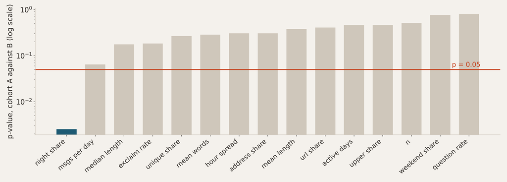

442 people in an IRC channel, split into cohort A and B. For each person 15 numbers: message length, links, questions, posting at night…

A t-test per number. One falls below 0.05: cohort A posts twice as much at night, 13.5% against 6.7% of messages, p = 0.003.

A story arrives at once: night owls, another time zone. Now look at how the cohorts were made: at random. There is no cohort.

4 / when should you believe a pattern?

MADS-DAV · 33

The trap, as the notebook sets it. Everyone in #ubuntu-uk with at least thirty messages, 442 people, and fifteen numbers per person. Each person also has a cohort label, A or B. Test every number between the cohorts, one Welch t-test each, and put the fifteen p-values on a log axis with the usual line at 0.05. One clears the line easily: cohort A does 13.5 percent of its posting between midnight and five in the morning, cohort B 6.7 percent, p = 0.0026, with more than two hundred people per group. That sounds publishable, and an explanation arrives immediately: night owls, or another time zone. Notice how fast the explanation came. Then the reveal: the cohort column was made with a random permutation. The two groups are the same population, split at random. Everything in this plot is produced by nothing at all.

■ 4 — when should you believe a pattern?

300 hunts over random labels

## How often do you find something when there is nothing?

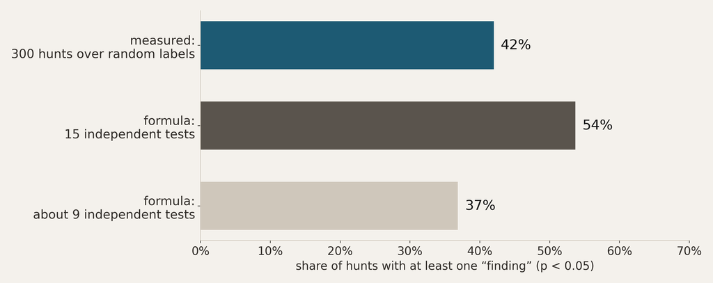

Shuffle the labels 300 times and hunt each time over the 15 measures. In 42% of the hunts at least one measure crosses 0.05.

The formula for 15 independent tests: all stay quiet 0.95¹⁵ = 46% of the time, so at least one alarm 54%.

The measured 42% is lower because the measures overlap: three are message length in disguise. They act like about 9 independent tests: 37%.

4 / when should you believe a pattern?

MADS-DAV · 34

Now measure instead of being surprised. Shuffle the cohort labels three hundred times and count, every time, how many of the fifteen measures come out below 0.05. In 42 percent of the hunts at least one does, some find two or three. That number is the sanity baseline: before asking whether a finding is real, ask how often you would have found something if there were nothing to find. If the answer is almost half the time, finding something is not evidence. The arithmetic: p below 0.05 means a false alarm one time in twenty per test. Fifteen tests all staying quiet is 0.95 to the fifteenth, 46 percent, so at least one alarm 54 percent. The trick worth remembering: 'at least one' is hard to count, 'none' is one product. The measured rate is lower because the measures are not independent: mean length, median length and mean words are three names for message size. They behave like about nine independent measures, and 1 minus 0.95 to the ninth is 37 percent.

■ 4 — when should you believe a pattern?

half the people to hunt in · half held out

## A real pattern predicts people it hasn’t seen

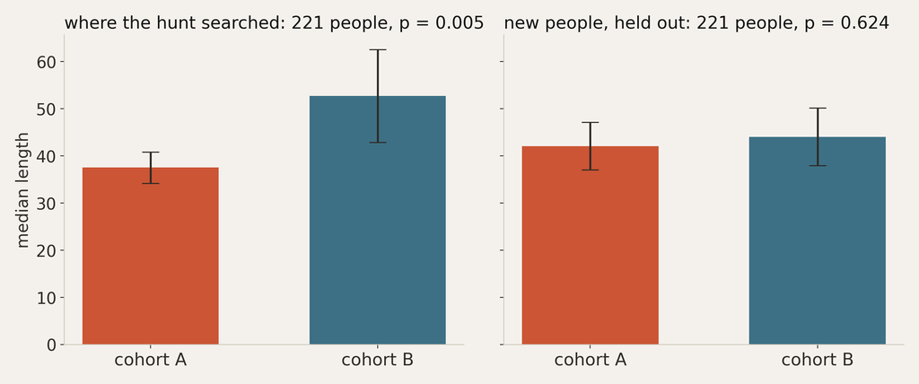

Random cohorts again. Hunt in half of the people: cohort A writes shorter messages, p = 0.005. It looks like a finding.

Now predict the other half, people the hunt never saw. The gap is gone: p = 0.62.

Over 200 random splits the hunt finds something 40% of the time, and the new people confirm it 2% of the time.

4 / when should you believe a pattern?

MADS-DAV · 35

The strongest defence: split the data, find the pattern in one part, then predict the other. Here with fresh random cohorts, so again there is nothing to find. Hunt over the fifteen measures in half of the people: cohort A writes clearly shorter messages, p = 0.005, a difference you would happily report. Then predict the other half, people the hunt never touched: the bars are level, p = 0.62. Over 200 random splits the hunt in the first half finds something below 0.05 in 40 percent of the splits, and the held-out people confirm it in 2 percent. A real pattern predicts new data; an accident of the search does not. One caution worth saying: the holdout has to be new units of the claim. Splitting the same people into an early and a late period is not enough, because the same people carry the same accidents into both periods; in this channel such a time split confirmed random cohort differences about one time in five. And the rule that goes with it: a finding and the search that produced it belong together, so say how many things you looked at.

■ 4 — when should you believe a pattern?

model · mechanism · replication

## Three legs make a finding believable

1 · model

A statistical model that fits: enough observations at the level of the claim, an effect bigger than chance. It can be evidence, if used well.

2 · mechanism

A reason it would be true, that you could have named before looking. No data gives you this.

3 · replication

It shows up where you didn’t look: another period, another group, another measure.

|  | survives testing | fails testing |
| --- | --- | --- |
| mechanism | Report it, then look for replication. | “Plausible, unproven.” A finished result: say what would settle it. |
| no mechanism | Don’t conclude yet. A fluke, or a variable you haven’t named. | Drop it. |

The two cells on the diagonal are obvious. The other two are the lesson: a null result is a result, and a significant result without a reason is a question.

4 / when should you believe a pattern?

MADS-DAV · 36

If the hunt were the whole story, the conclusion would be that nothing is ever real, which is as bad as believing everything. So what would make you believe a finding? Three legs, and a statistical model supplies at most one. A model: enough observations at the unit the claim is about, an effect bigger than chance makes. Mechanism: a reason it would be true that you could have named before you looked; no amount of data supplies this leg. Replication: it appears where you did not look, in another period, another channel, another way of measuring. Cross the first two. Mechanism and it survives testing: report it, then go and check replication. No mechanism and it fails: drop it. The off-diagonal cells are what students almost never write down. A mechanism that fails testing is 'plausible, unproven', and that is a finished result if you say what would settle it. A significant result with no mechanism is not a conclusion: it is a fluke or a confounder you have not named, and the confounder is usually the more interesting finding. The COVID switch: a model that fits, a mechanism yes, replication not yet.

■ 4 — when should you believe a pattern?

claim 1 · ubuntu release days

## The comparison you choose is part of the claim

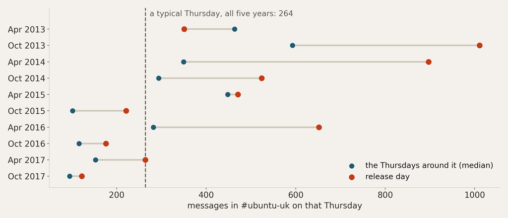

Claim: Ubuntu release days are busier. Mechanism: strong, the dates are set by Ubuntu, not by the chat.

Against a typical Thursday of all five years (the dashed line), only 6 of 10 release days are busier. But the channel got much quieter over the years.

Against the Thursdays around each release: 9 of 10 busier, 1.7× on average, p = 0.02. Same data; only “typical” changed.

4 / when should you believe a pattern?

MADS-DAV · 37

First claim through the grid. Ubuntu releases on a Thursday, twice a year, on dates fixed in advance by a calendar the chat has no say in: a strong mechanism, ten near-independent instances. The obvious test compares each release day with a typical Thursday. Over all five years, the median Thursday has 264 messages, and only six of the ten releases beat it: a coin flip, which would kill the claim. It should not, because the channel lost most of its traffic over these years: a typical Thursday in 2013 and in 2017 are different numbers, and the late releases are compared with a median that mostly comes from the busy early years. The trend is a confounder for the event. Compare each release with the Thursdays within four weeks around it instead: nine of ten are busier, by 1.7 times on average, and a sign test gives p = 0.02. The sign test only asks which side of typical each day falls on, a question ten noisy days can answer. Last week said a baseline can invent a finding; this is the mirror: a baseline can also destroy one.

■ 4 — when should you believe a pattern?

claim 3 · one number per person

## Test at the level of your claim

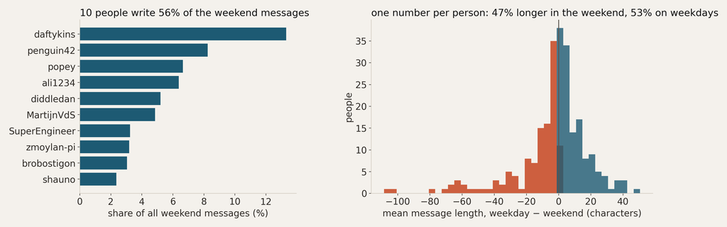

Per message, weekend messages are longer: 49.2 against 48.2 characters, p = 0.000000001 over 510,833 messages.

But ten people write 56% of the weekend messages. Bill Gates walks into a bar: on average everyone is a millionaire.

One number per person: 47% write longer in the weekend, 53% on weekdays. It is about a few people, not about people.

4 / when should you believe a pattern?

MADS-DAV · 38

The claim: message length differs between weekdays and weekends. Per message the answer looks decisive: weekend messages are about one character longer, with a p-value of ten to the minus nine over half a million messages. But a message average is dominated by whoever writes the most. Ten people write 56 percent of all weekend messages, and who posts in the weekend is not who posts on weekdays. If every weekend poster wrote exactly as they do on weekdays, the weekend average would already be 48.9 instead of 48.2: most of the difference is who is talking, not how people talk. That is Bill Gates walking into a bar: the average wealth goes through the roof and nobody in the bar got richer. Ask the question at the level of the claim, one number per person, and it splits: 47 percent write longer in the weekend, 53 percent on weekdays, paired p = 0.06. This says something about a few heavy posters, not about people. Report it that way: no general difference between weekday and weekend writing for the 259 people with enough messages; the per-message difference comes from who posts when.

● 04 — again, concretely

Spurious correlations should be expected.

Ask how often you would find something if there were nothing. Shuffle the labels to measure it.

39

Said again. The baseline question from last week, what would I see if there were nothing here, now for many comparisons at once. Then the three legs, applied to today's model: the switch fits and has a mechanism, but one country on one calendar cannot separate vaccination from everything else that happened that spring.

▲ question 05

what can a correlation hide?

## Be careful: a correlation on its own is not reliable.

1 · Statistician’s nightmare

A correlation summarises two columns. It can look strong and mean nothing, or look weak and hide a real relation, and the number alone does not tell you which.

2 · Subgroups

Always ask which groups are mixed in your data. A subgroup you didn’t separate can turn a correlation around.

3 · Regularisation

With many features, a regression with a penalty on its weights finds the useful ones better than correlations do.

40

Question five, notebook 05.2, and the message is a warning: a correlation on its own is not reliable. Pearson's r says how two columns move together, scaled between minus one and one, and it is the first plot everyone makes. It can look strong and mean nothing, or look weak and hide a real relation, and the number alone does not tell you which. That is what keeps statisticians awake at night. Two habits help. Always think about subgroups: which groups are mixed in your data, and does the correlation hold inside each of them? And with many features, use a trick: a regression with a penalty on its weights picks out the useful features better than correlations do. Both come next, with penguins and with simulated data.

■ 5 — what can a correlation hide?

palmer penguins · 324 birds

## The same penguins, twice: the line turns around

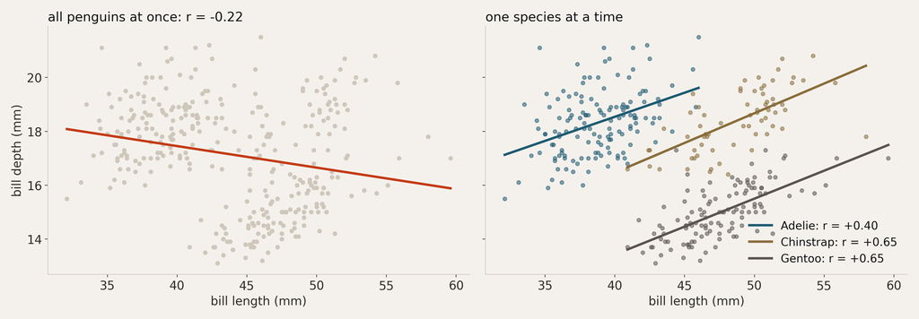

Left: all penguins at once. Longer bills are shallower: r = −0.22.

Right: one species at a time. In every species a longer bill is deeper: +0.40, +0.65, +0.65.

Gentoos have long, shallow bills, Adelies short, deep ones. The pooled line measures the difference between species. This is Simpson’s paradox.

5 / what can a correlation hide?

MADS-DAV · 41

The correlation matrix in 05.2 is computed on the numeric columns only: species, island and sex are text and were dropped before a single correlation was computed. So every number in it mixes three species. Bill length against bill depth: pooled, minus 0.22, longer bills are shallower. Within each species: plus 0.40 for Adelie, 0.65 for Chinstrap and Gentoo; longer bills are deeper. Nothing about the birds changed. The pooled line is measuring that Gentoos have long, shallow bills and Adelies short, deep ones, which lays the three clouds along a downward diagonal. This is Simpson's paradox, which lesson 2 met as a table of admissions; as a scatter you can see the mechanism: three clouds and one line drawn through them.

■ 5 — what can a correlation hide?

15 correlations · pooled and within species